# R - Programming with the Tidyverse

Michael Luu & Marcio Diniz

2020-01-13

# Workflow in statistical analysis

# What is the tidyverse ?

[figure not shown]

A collection of packages that are used to faciliate data exploration, visualization, and ‘tidying’ of your data.

- **dplyr** - manipulation of data
- **ggplot2** - visualiation of data
- **readr** - importing data into R
- **tibble** - creation of dataframes in R
- **tidyr** - ‘tidying’ or ‘cleaning’ your data
- **purrr** - functional or iterative programming in R

# What is ‘tidy’ data ?

- Every column should consist of a variable with a single type of data e.g. logical, dbl, integer, character, etc.
- Every row should consist of a single observation.
- Every cell should consist of a single value type.

# `dplyr` overview

These are the four main `dplyr` functions that we will use to perform the vast majority of data manipulations

- **select observations by their values `filter()`**

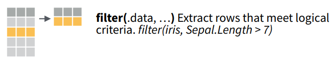

- **select variables by their names `select()`**

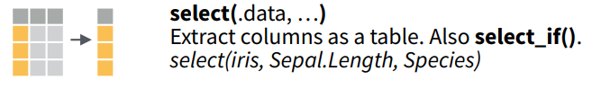

- **create new variables as functions of other variables `mutate()`**

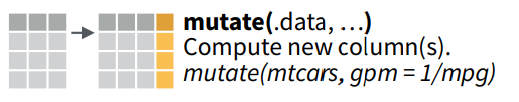

- **collapse values down to a summary `summarise()`**

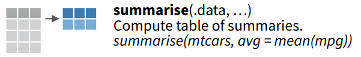

# `tidyr` overview

These are the two main `tidyr` functions we will be using

- **collapse data from wide to long format `pivot_longer()`**

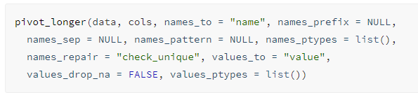

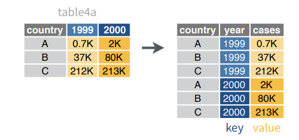

- **expand data from long to wide format `pivot_wider()`**

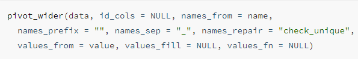

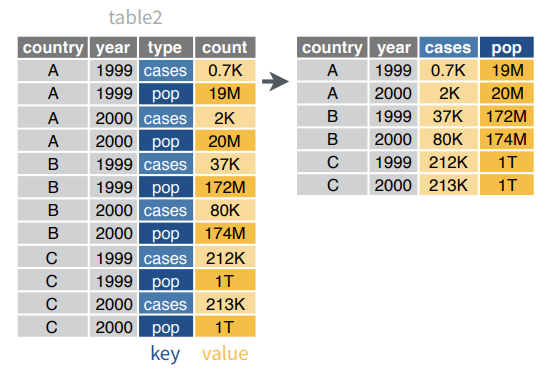

# The `%>%` (pipe) operator

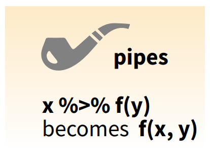

The pipe operator allows us to chain together multiple functions together. Think of the pipe operator as a method of passing the output of a function to the next function

# Installing the ‘tidyverse’ package

Before we have access to the ‘tidyverse’ functions that was mentioned - we will first need to install the package using the `install.packages()` function. This is a generic function that you can use to install **ANY** packages you learn about in the future that is part of CRAN. You can install any package by adding the name of the package between quotes, within the parantheses. e.g. ‘tidyverse’

```r
# install.packages('tidyverse')
```

# Loading the ‘tidyverse’ package

Now that the tidyverse packages have been installed into R, you will need to load the package to get access to the function. You won’t have access to any of the functions until you load the package.

```r
# library(tidyverse)
```

# Looking up the documentation of any function

If you ever have any questions or trouble utilizing any of the functions, you can easily look up the help page for that specific function by adding a question mark before the name of the function.

```r
# ?glimpse
```

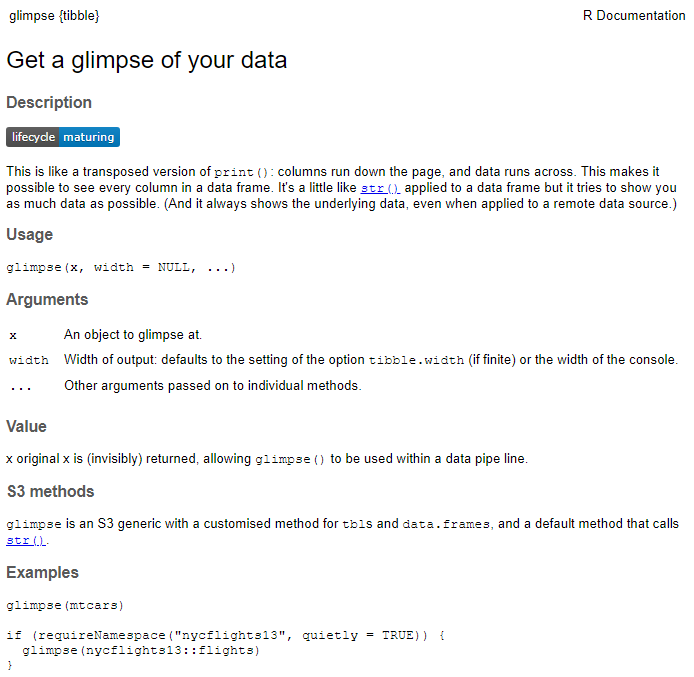

# Case study with the sepsis data

## Reading in the data

```r
## reading in the dataset, an alternative method of accessing a function within a package is to use the double colon ::, you type the package name e.g. readxl, followed by double colons :: and then the function. Here we are using the read_excel() function from the readxl package
df <- readxl::read_excel('data/sepsis_original.xlsx', na = 'NA')

## here we are using the janitor package to help us clean the variable names of the data
df <- janitor::clean_names(df)

## obtaining a glimpse of the dataframe, this allows us to have a quick 'glimpse' or look of the data we just imported
glimpse(df)
```

```
Observations: 455
Variables: 21
$ id     <dbl> 1, 2, 3, 4, 5, 6, 7, 8, 9, 10, 11, 12, 13, 14, 15, 16, ...
$ treat  <dbl> 0, 1, 0, 1, 0, 1, 1, 0, 1, 0, 1, 0, 1, 0, 1, 0, 0, 0, 1...
$ race   <dbl> 0, 1, 1, 0, 0, 0, 0, 0, 0, 0, 0, 0, 0, 0, 0, 0, 1, 0, 0...
$ apache <dbl> 27, 14, 33, 3, 5, 13, 34, 11, 25, 20, 21, 14, 19, 23, 2...
$ death  <dbl> 1, 0, 1, 0, 0, 0, 1, 0, 0, 0, 0, 0, 1, 0, 1, 1, 0, 0, 0...
$ temp0  <dbl> 95.4, 101.6, 101.0, 101.0, 101.4, 100.7, 101.1, 100.9, ...
$ temp1  <dbl> 93.9, 99.0, 98.9, 100.2, 101.4, 101.0, 99.7, 100.3, 99....
$ temp2  <dbl> 93.6, 99.8, 97.2, 100.0, 101.8, 101.5, 99.5, 100.7, 99....
$ temp3  <dbl> 93.0, 99.8, NA, 99.5, 101.4, 102.1, 99.0, 100.3, 99.7, ...
$ temp4  <dbl> 90.3, 99.6, NA, 99.7, 101.4, 102.3, 99.1, 99.1, 99.0, 9...
$ temp5  <dbl> 93.2, 100.2, 94.8, 99.1, 101.0, 99.9, 98.7, 98.9, 98.1,...
$ temp6  <dbl> 95.0, 100.2, 95.5, 99.3, 102.6, 100.5, 99.1, 99.3, 98.9...
$ temp7  <dbl> 96.2, 99.0, NA, 99.6, 100.8, 101.5, 98.3, 100.1, 98.1, ...
$ temp8  <dbl> 98.8, 99.9, 97.2, 98.0, 100.6, 101.9, 99.1, 100.3, 98.0...
$ temp9  <dbl> 97.5, 99.8, 99.2, 97.8, 99.8, 99.5, 99.0, 99.3, 98.1, 1...
$ temp10 <dbl> 97.8, 99.6, NA, 97.6, 99.6, 100.7, 98.1, 98.7, 98.1, 99...
$ temp11 <dbl> 99.1, 99.4, NA, 98.4, 99.6, 101.3, 99.0, 98.5, 97.8, 10...
$ temp12 <dbl> 95.6, 101.2, NA, 98.0, 99.8, 101.5, 98.9, 99.0, 97.8, 9...
$ temp13 <dbl> NA, 101.0, NA, 98.4, 100.8, 101.5, NA, 98.6, 98.0, 102....
$ temp14 <dbl> NA, NA, NA, NA, NA, NA, NA, NA, NA, NA, NA, NA, NA, NA,...
$ temp15 <dbl> NA, 100.6, NA, 98.8, 100.0, 101.5, NA, 99.0, 98.0, 101....
```

```r
## we can see that treat, race, and death are incorrectly coded as 'dbl', we would like to change them into factors using the factors() function. Since we are replacing the previous values with a new one, we need to use it in conjunction with the mutate function to create a new variable

df <-
  mutate(df, treat = factor(
    treat,
    levels = c(0, 1),
    labels = c('0' = 'Control', '1' = 'Ibuprofenol')
  ))

df <- mutate(df, race = factor(
  race,
  levels = c(0, 1, 2),
  labels = c('0' = 'White', '1' = 'African American', '2' = 'Hispanic')
))

df <- mutate(df, death = factor(
  death,
  levels = c(0, 1),
  labels = c('0' = 'Alive', '1' = 'Died')
))

## obtain a new glimpse of the data to confirm the variables contain the correct 'typing'
glimpse(df)
```

```
Observations: 455
Variables: 21
$ id     <dbl> 1, 2, 3, 4, 5, 6, 7, 8, 9, 10, 11, 12, 13, 14, 15, 16, ...
$ treat  <fct> Control, Ibuprofenol, Control, Ibuprofenol, Control, Ib...
$ race   <fct> White, African American, African American, White, White...
$ apache <dbl> 27, 14, 33, 3, 5, 13, 34, 11, 25, 20, 21, 14, 19, 23, 2...
$ death  <fct> Died, Alive, Died, Alive, Alive, Alive, Died, Alive, Al...
$ temp0  <dbl> 95.4, 101.6, 101.0, 101.0, 101.4, 100.7, 101.1, 100.9, ...
$ temp1  <dbl> 93.9, 99.0, 98.9, 100.2, 101.4, 101.0, 99.7, 100.3, 99....
$ temp2  <dbl> 93.6, 99.8, 97.2, 100.0, 101.8, 101.5, 99.5, 100.7, 99....
$ temp3  <dbl> 93.0, 99.8, NA, 99.5, 101.4, 102.1, 99.0, 100.3, 99.7, ...
$ temp4  <dbl> 90.3, 99.6, NA, 99.7, 101.4, 102.3, 99.1, 99.1, 99.0, 9...
$ temp5  <dbl> 93.2, 100.2, 94.8, 99.1, 101.0, 99.9, 98.7, 98.9, 98.1,...
$ temp6  <dbl> 95.0, 100.2, 95.5, 99.3, 102.6, 100.5, 99.1, 99.3, 98.9...
$ temp7  <dbl> 96.2, 99.0, NA, 99.6, 100.8, 101.5, 98.3, 100.1, 98.1, ...
$ temp8  <dbl> 98.8, 99.9, 97.2, 98.0, 100.6, 101.9, 99.1, 100.3, 98.0...
$ temp9  <dbl> 97.5, 99.8, 99.2, 97.8, 99.8, 99.5, 99.0, 99.3, 98.1, 1...
$ temp10 <dbl> 97.8, 99.6, NA, 97.6, 99.6, 100.7, 98.1, 98.7, 98.1, 99...
$ temp11 <dbl> 99.1, 99.4, NA, 98.4, 99.6, 101.3, 99.0, 98.5, 97.8, 10...
$ temp12 <dbl> 95.6, 101.2, NA, 98.0, 99.8, 101.5, 98.9, 99.0, 97.8, 9...
$ temp13 <dbl> NA, 101.0, NA, 98.4, 100.8, 101.5, NA, 98.6, 98.0, 102....
$ temp14 <dbl> NA, NA, NA, NA, NA, NA, NA, NA, NA, NA, NA, NA, NA, NA,...
$ temp15 <dbl> NA, 100.6, NA, 98.8, 100.0, 101.5, NA, 99.0, 98.0, 101....
```

## Converting the temperature from F to C

```r
## we can write the formula to convert a single temp from F to C
mutate(df, temp0 = (temp0 - 32) * 5/9)
```

```
# A tibble: 455 x 21
      id treat race  apache death temp0 temp1 temp2 temp3 temp4 temp5 temp6
   <dbl> <fct> <fct>  <dbl> <fct> <dbl> <dbl> <dbl> <dbl> <dbl> <dbl> <dbl>
 1     1 Cont~ White     27 Died   35.2  93.9  93.6  93    90.3  93.2  95
 2     2 Ibup~ Afri~     14 Alive  38.7  99    99.8  99.8  99.6 100.  100.
 3     3 Cont~ Afri~     33 Died   38.3  98.9  97.2  NA    NA    94.8  95.5
 4     4 Ibup~ White      3 Alive  38.3 100.  100    99.5  99.7  99.1  99.3
 5     5 Cont~ White      5 Alive  38.6 101.  102.  101.  101.  101   103.
 6     6 Ibup~ White     13 Alive  38.2 101   102.  102.  102.   99.9 100.
 7     7 Ibup~ White     34 Died   38.4  99.7  99.5  99    99.1  98.7  99.1
 8     8 Cont~ White     11 Alive  38.3 100.  101.  100.   99.1  98.9  99.3
 9     9 Ibup~ White     25 Alive  38.2  99.7  99.9  99.7  99    98.1  98.9
10    10 Cont~ White     20 Alive  37.2  98    97    99.6  99.6 100    99
# ... with 445 more rows, and 9 more variables: temp7 <dbl>, temp8 <dbl>,
#   temp9 <dbl>, temp10 <dbl>, temp11 <dbl>, temp12 <dbl>, temp13 <dbl>,
#   temp14 <dbl>, temp15 <dbl>
```

```r
## alternatively we can write our own function to do this
fare_to_cel <- function(x) {
  (x - 32) * 5/9
}

## and then apply the function to the selected variables using a 'cousin' of the mutate function
## use ?mutate_at() to get more information on how to use this function
## the below three methods all produce the same results

df %>% mutate_at(
  .,
  c(
    "temp0",
    "temp1",
    "temp2",
    "temp3",
    "temp4",
    "temp5",
    "temp6",
    "temp7",
    "temp8",
    "temp9",
    "temp10",
    "temp11",
    "temp12",
    "temp13",
    "temp14",
    "temp15"
  ),
  fare_to_cel
)
```

```
# A tibble: 455 x 21
      id treat race  apache death temp0 temp1 temp2 temp3 temp4 temp5 temp6
   <dbl> <fct> <fct>  <dbl> <fct> <dbl> <dbl> <dbl> <dbl> <dbl> <dbl> <dbl>
 1     1 Cont~ White     27 Died   35.2  34.4  34.2  33.9  32.4  34.0  35
 2     2 Ibup~ Afri~     14 Alive  38.7  37.2  37.7  37.7  37.6  37.9  37.9
 3     3 Cont~ Afri~     33 Died   38.3  37.2  36.2  NA    NA    34.9  35.3
 4     4 Ibup~ White      3 Alive  38.3  37.9  37.8  37.5  37.6  37.3  37.4
 5     5 Cont~ White      5 Alive  38.6  38.6  38.8  38.6  38.6  38.3  39.2
 6     6 Ibup~ White     13 Alive  38.2  38.3  38.6  38.9  39.1  37.7  38.1
 7     7 Ibup~ White     34 Died   38.4  37.6  37.5  37.2  37.3  37.1  37.3
 8     8 Cont~ White     11 Alive  38.3  37.9  38.2  37.9  37.3  37.2  37.4
 9     9 Ibup~ White     25 Alive  38.2  37.6  37.7  37.6  37.2  36.7  37.2
10    10 Cont~ White     20 Alive  37.2  36.7  36.1  37.6  37.6  37.8  37.2
# ... with 445 more rows, and 9 more variables: temp7 <dbl>, temp8 <dbl>,
#   temp9 <dbl>, temp10 <dbl>, temp11 <dbl>, temp12 <dbl>, temp13 <dbl>,
#   temp14 <dbl>, temp15 <dbl>
```

```r
df %>% mutate_at(., 6:21, fare_to_cel)
```

```
# A tibble: 455 x 21
      id treat race  apache death temp0 temp1 temp2 temp3 temp4 temp5 temp6
   <dbl> <fct> <fct>  <dbl> <fct> <dbl> <dbl> <dbl> <dbl> <dbl> <dbl> <dbl>
 1     1 Cont~ White     27 Died   35.2  34.4  34.2  33.9  32.4  34.0  35
 2     2 Ibup~ Afri~     14 Alive  38.7  37.2  37.7  37.7  37.6  37.9  37.9
 3     3 Cont~ Afri~     33 Died   38.3  37.2  36.2  NA    NA    34.9  35.3
 4     4 Ibup~ White      3 Alive  38.3  37.9  37.8  37.5  37.6  37.3  37.4
 5     5 Cont~ White      5 Alive  38.6  38.6  38.8  38.6  38.6  38.3  39.2
 6     6 Ibup~ White     13 Alive  38.2  38.3  38.6  38.9  39.1  37.7  38.1
 7     7 Ibup~ White     34 Died   38.4  37.6  37.5  37.2  37.3  37.1  37.3
 8     8 Cont~ White     11 Alive  38.3  37.9  38.2  37.9  37.3  37.2  37.4
 9     9 Ibup~ White     25 Alive  38.2  37.6  37.7  37.6  37.2  36.7  37.2
10    10 Cont~ White     20 Alive  37.2  36.7  36.1  37.6  37.6  37.8  37.2
# ... with 445 more rows, and 9 more variables: temp7 <dbl>, temp8 <dbl>,
#   temp9 <dbl>, temp10 <dbl>, temp11 <dbl>, temp12 <dbl>, temp13 <dbl>,
#   temp14 <dbl>, temp15 <dbl>
```

```r
df %>% mutate_at(., vars(temp0:temp15), fare_to_cel)
```

```
# A tibble: 455 x 21
      id treat race  apache death temp0 temp1 temp2 temp3 temp4 temp5 temp6
   <dbl> <fct> <fct>  <dbl> <fct> <dbl> <dbl> <dbl> <dbl> <dbl> <dbl> <dbl>
 1     1 Cont~ White     27 Died   35.2  34.4  34.2  33.9  32.4  34.0  35
 2     2 Ibup~ Afri~     14 Alive  38.7  37.2  37.7  37.7  37.6  37.9  37.9
 3     3 Cont~ Afri~     33 Died   38.3  37.2  36.2  NA    NA    34.9  35.3
 4     4 Ibup~ White      3 Alive  38.3  37.9  37.8  37.5  37.6  37.3  37.4
 5     5 Cont~ White      5 Alive  38.6  38.6  38.8  38.6  38.6  38.3  39.2
 6     6 Ibup~ White     13 Alive  38.2  38.3  38.6  38.9  39.1  37.7  38.1
 7     7 Ibup~ White     34 Died   38.4  37.6  37.5  37.2  37.3  37.1  37.3
 8     8 Cont~ White     11 Alive  38.3  37.9  38.2  37.9  37.3  37.2  37.4
 9     9 Ibup~ White     25 Alive  38.2  37.6  37.7  37.6  37.2  36.7  37.2
10    10 Cont~ White     20 Alive  37.2  36.7  36.1  37.6  37.6  37.8  37.2
# ... with 445 more rows, and 9 more variables: temp7 <dbl>, temp8 <dbl>,
#   temp9 <dbl>, temp10 <dbl>, temp11 <dbl>, temp12 <dbl>, temp13 <dbl>,
#   temp14 <dbl>, temp15 <dbl>
```

```r
## if we are content with the changes, we can save and replace our original dataframe with the changes
df <- df %>% mutate_at(., vars(temp0:temp15), fare_to_cel)
```

## Transforming from wide to long and back

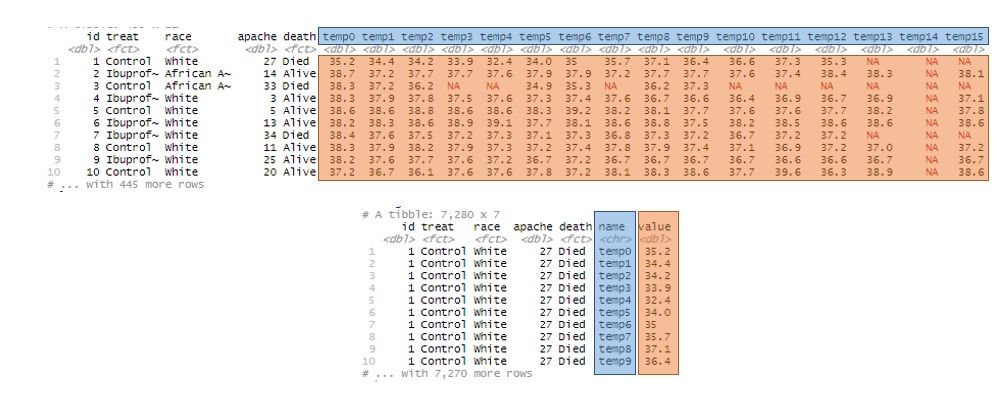

We can use the `pivot_longer()` and the `pivot_wider()` function to transpose our data between the two data structure. The `pivot_longer()` function will transpose a wide dataframe to a long dataframe. The `pivot_wider()` function will allow for the opposite, a long dataframe to a wide dataframe.

```r
## here we are creating a new dataframe called 'long'
long <- df %>% pivot_longer(., cols = temp0:temp15, names_to = 'name', values_to = 'value')
long
```

```
# A tibble: 7,280 x 7
      id treat   race  apache death name  value
   <dbl> <fct>   <fct>  <dbl> <fct> <chr> <dbl>
 1     1 Control White     27 Died  temp0  35.2
 2     1 Control White     27 Died  temp1  34.4
 3     1 Control White     27 Died  temp2  34.2
 4     1 Control White     27 Died  temp3  33.9
 5     1 Control White     27 Died  temp4  32.4
 6     1 Control White     27 Died  temp5  34.0
 7     1 Control White     27 Died  temp6  35
 8     1 Control White     27 Died  temp7  35.7
 9     1 Control White     27 Died  temp8  37.1
10     1 Control White     27 Died  temp9  36.4
# ... with 7,270 more rows
```

```r
## here we are creating a new dataframe called 'wide' by converting the long dataframe back to wide format
## they are both valid formats we can work with in R

wide <- long %>% pivot_wider(., names_from = 'name', values_from = 'value')
wide
```

```
# A tibble: 455 x 21
      id treat race  apache death temp0 temp1 temp2 temp3 temp4 temp5 temp6
   <dbl> <fct> <fct>  <dbl> <fct> <dbl> <dbl> <dbl> <dbl> <dbl> <dbl> <dbl>
 1     1 Cont~ White     27 Died   35.2  34.4  34.2  33.9  32.4  34.0  35
 2     2 Ibup~ Afri~     14 Alive  38.7  37.2  37.7  37.7  37.6  37.9  37.9
 3     3 Cont~ Afri~     33 Died   38.3  37.2  36.2  NA    NA    34.9  35.3
 4     4 Ibup~ White      3 Alive  38.3  37.9  37.8  37.5  37.6  37.3  37.4
 5     5 Cont~ White      5 Alive  38.6  38.6  38.8  38.6  38.6  38.3  39.2
 6     6 Ibup~ White     13 Alive  38.2  38.3  38.6  38.9  39.1  37.7  38.1
 7     7 Ibup~ White     34 Died   38.4  37.6  37.5  37.2  37.3  37.1  37.3
 8     8 Cont~ White     11 Alive  38.3  37.9  38.2  37.9  37.3  37.2  37.4
 9     9 Ibup~ White     25 Alive  38.2  37.6  37.7  37.6  37.2  36.7  37.2
10    10 Cont~ White     20 Alive  37.2  36.7  36.1  37.6  37.6  37.8  37.2
# ... with 445 more rows, and 9 more variables: temp7 <dbl>, temp8 <dbl>,
#   temp9 <dbl>, temp10 <dbl>, temp11 <dbl>, temp12 <dbl>, temp13 <dbl>,
#   temp14 <dbl>, temp15 <dbl>
```

## Extracting specific observations

```r
## to extract specific observations we can use the filter() function, and state a criteria. Here we are extracting only patients in the Control group
df %>% filter(., treat == 'Control')
```

```
# A tibble: 231 x 21
      id treat race  apache death temp0 temp1 temp2 temp3 temp4 temp5 temp6
   <dbl> <fct> <fct>  <dbl> <fct> <dbl> <dbl> <dbl> <dbl> <dbl> <dbl> <dbl>
 1     1 Cont~ White     27 Died   35.2  34.4  34.2  33.9  32.4  34.0  35
 2     3 Cont~ Afri~     33 Died   38.3  37.2  36.2  NA    NA    34.9  35.3
 3     5 Cont~ White      5 Alive  38.6  38.6  38.8  38.6  38.6  38.3  39.2
 4     8 Cont~ White     11 Alive  38.3  37.9  38.2  37.9  37.3  37.2  37.4
 5    10 Cont~ White     20 Alive  37.2  36.7  36.1  37.6  37.6  37.8  37.2
 6    12 Cont~ White     14 Alive  38.6  38.7  39.2  39.1  39.1  39.7  38.3
 7    14 Cont~ White     23 Alive  37.9  37.6  37.4  37.4  37.4  37.6  37.6
 8    16 Cont~ White     16 Died   38.1  38.0  37.7  36.9  36.9  36.4  NA
 9    17 Cont~ Afri~     17 Alive  38.1  37.7  38.3  37.8  39.3  37.6  38.2
10    18 Cont~ White     14 Alive  38.7  38.7  38.6  38.3  38.3  38.3  38.4
# ... with 221 more rows, and 9 more variables: temp7 <dbl>, temp8 <dbl>,
#   temp9 <dbl>, temp10 <dbl>, temp11 <dbl>, temp12 <dbl>, temp13 <dbl>,
#   temp14 <dbl>, temp15 <dbl>
```

```r
## here we are extracting white control patients
df %>% filter(., treat == 'Control' & race == 'White')
```

```
# A tibble: 156 x 21
      id treat race  apache death temp0 temp1 temp2 temp3 temp4 temp5 temp6
   <dbl> <fct> <fct>  <dbl> <fct> <dbl> <dbl> <dbl> <dbl> <dbl> <dbl> <dbl>
 1     1 Cont~ White     27 Died   35.2  34.4  34.2  33.9  32.4  34.0  35
 2     5 Cont~ White      5 Alive  38.6  38.6  38.8  38.6  38.6  38.3  39.2
 3     8 Cont~ White     11 Alive  38.3  37.9  38.2  37.9  37.3  37.2  37.4
 4    10 Cont~ White     20 Alive  37.2  36.7  36.1  37.6  37.6  37.8  37.2
 5    12 Cont~ White     14 Alive  38.6  38.7  39.2  39.1  39.1  39.7  38.3
 6    14 Cont~ White     23 Alive  37.9  37.6  37.4  37.4  37.4  37.6  37.6
 7    16 Cont~ White     16 Died   38.1  38.0  37.7  36.9  36.9  36.4  NA
 8    18 Cont~ White     14 Alive  38.7  38.7  38.6  38.3  38.3  38.3  38.4
 9    21 Cont~ White     24 Died   39.3  39.4  39.8  39.9  38.6  36.8  36.8
10    23 Cont~ White     14 Alive  38.4  38.7  38.2  37.8  38.2  36.8  38.1
# ... with 146 more rows, and 9 more variables: temp7 <dbl>, temp8 <dbl>,
#   temp9 <dbl>, temp10 <dbl>, temp11 <dbl>, temp12 <dbl>, temp13 <dbl>,
#   temp14 <dbl>, temp15 <dbl>
```

```r
## here we are extracting white control patients who died
df %>% filter(., treat == 'Control' & race == 'White' & death == 'Died')
```

```
# A tibble: 54 x 21
      id treat race  apache death temp0 temp1 temp2 temp3 temp4 temp5 temp6
   <dbl> <fct> <fct>  <dbl> <fct> <dbl> <dbl> <dbl> <dbl> <dbl> <dbl> <dbl>
 1     1 Cont~ White     27 Died   35.2  34.4  34.2  33.9  32.4  34.0  35
 2    16 Cont~ White     16 Died   38.1  38.0  37.7  36.9  36.9  36.4  NA
 3    21 Cont~ White     24 Died   39.3  39.4  39.8  39.9  38.6  36.8  36.8
 4    27 Cont~ White     18 Died   38.3  37.6  37.6  36.8  37.7  36.7  38.0
 5    56 Cont~ White     18 Died   39.1  39.3  39.5  39.5  39.8  39.6  39.9
 6    80 Cont~ White     27 Died   37.7  37.7  37.2  37.9  38.2  37.9  37.8
 7    82 Cont~ White      8 Died   38.1  36.4  36.6  34.4  33.0  34.4  34.8
 8    89 Cont~ White     21 Died   34.6  37.3  37.4  37.6  37.1  37.4  37.4
 9   102 Cont~ White     15 Died   38.6  38.5  38.6  38.3  37.6  37.1  36.7
10   104 Cont~ White      7 Died   38.0  38.0  38.0  38.2  37.7  37.3  39.0
# ... with 44 more rows, and 9 more variables: temp7 <dbl>, temp8 <dbl>,
#   temp9 <dbl>, temp10 <dbl>, temp11 <dbl>, temp12 <dbl>, temp13 <dbl>,
#   temp14 <dbl>, temp15 <dbl>
```

```r
## here we are extracting white control patients with apache score greater than 10 or who died
df %>% filter(., (treat == 'Control' & race == 'White' ) & (apache > 10 | death == 'Died'))
```

```
# A tibble: 121 x 21
      id treat race  apache death temp0 temp1 temp2 temp3 temp4 temp5 temp6
   <dbl> <fct> <fct>  <dbl> <fct> <dbl> <dbl> <dbl> <dbl> <dbl> <dbl> <dbl>
 1     1 Cont~ White     27 Died   35.2  34.4  34.2  33.9  32.4  34.0  35
 2     8 Cont~ White     11 Alive  38.3  37.9  38.2  37.9  37.3  37.2  37.4
 3    10 Cont~ White     20 Alive  37.2  36.7  36.1  37.6  37.6  37.8  37.2
 4    12 Cont~ White     14 Alive  38.6  38.7  39.2  39.1  39.1  39.7  38.3
 5    14 Cont~ White     23 Alive  37.9  37.6  37.4  37.4  37.4  37.6  37.6
 6    16 Cont~ White     16 Died   38.1  38.0  37.7  36.9  36.9  36.4  NA
 7    18 Cont~ White     14 Alive  38.7  38.7  38.6  38.3  38.3  38.3  38.4
 8    21 Cont~ White     24 Died   39.3  39.4  39.8  39.9  38.6  36.8  36.8
 9    23 Cont~ White     14 Alive  38.4  38.7  38.2  37.8  38.2  36.8  38.1
10    25 Cont~ White     22 Alive  35.7  36.8  37.4  38.3  38.4  37.9  37.4
# ... with 111 more rows, and 9 more variables: temp7 <dbl>, temp8 <dbl>,
#   temp9 <dbl>, temp10 <dbl>, temp11 <dbl>, temp12 <dbl>, temp13 <dbl>,
#   temp14 <dbl>, temp15 <dbl>
```

## Selecting specific columns or variables

```r
## perhaps we wanted to extract a dataframe that only contains id, treat, race, apache, and death
df %>% select(., id, treat, race, apache, death)
```

```
# A tibble: 455 x 5
      id treat       race             apache death
   <dbl> <fct>       <fct>             <dbl> <fct>
 1     1 Control     White                27 Died
 2     2 Ibuprofenol African American     14 Alive
 3     3 Control     African American     33 Died
 4     4 Ibuprofenol White                 3 Alive
 5     5 Control     White                 5 Alive
 6     6 Ibuprofenol White                13 Alive
 7     7 Ibuprofenol White                34 Died
 8     8 Control     White                11 Alive
 9     9 Ibuprofenol White                25 Alive
10    10 Control     White                20 Alive
# ... with 445 more rows
```

```r
## perhaps we wanted to extract only the id and the temp variables
df %>% select(., id, temp0:temp15)
```

```
# A tibble: 455 x 17
      id temp0 temp1 temp2 temp3 temp4 temp5 temp6 temp7 temp8 temp9 temp10
   <dbl> <dbl> <dbl> <dbl> <dbl> <dbl> <dbl> <dbl> <dbl> <dbl> <dbl>  <dbl>
 1     1  35.2  34.4  34.2  33.9  32.4  34.0  35    35.7  37.1  36.4   36.6
 2     2  38.7  37.2  37.7  37.7  37.6  37.9  37.9  37.2  37.7  37.7   37.6
 3     3  38.3  37.2  36.2  NA    NA    34.9  35.3  NA    36.2  37.3   NA
 4     4  38.3  37.9  37.8  37.5  37.6  37.3  37.4  37.6  36.7  36.6   36.4
 5     5  38.6  38.6  38.8  38.6  38.6  38.3  39.2  38.2  38.1  37.7   37.6
 6     6  38.2  38.3  38.6  38.9  39.1  37.7  38.1  38.6  38.8  37.5   38.2
 7     7  38.4  37.6  37.5  37.2  37.3  37.1  37.3  36.8  37.3  37.2   36.7
 8     8  38.3  37.9  38.2  37.9  37.3  37.2  37.4  37.8  37.9  37.4   37.1
 9     9  38.2  37.6  37.7  37.6  37.2  36.7  37.2  36.7  36.7  36.7   36.7
10    10  37.2  36.7  36.1  37.6  37.6  37.8  37.2  38.1  38.3  38.6   37.7
# ... with 445 more rows, and 5 more variables: temp11 <dbl>,
#   temp12 <dbl>, temp13 <dbl>, temp14 <dbl>, temp15 <dbl>
```

```r
## perhaps we wanted to extract all the variables except outcome e.g. death
df %>% select(., -death)
```

```
# A tibble: 455 x 20
      id treat race  apache temp0 temp1 temp2 temp3 temp4 temp5 temp6 temp7
   <dbl> <fct> <fct>  <dbl> <dbl> <dbl> <dbl> <dbl> <dbl> <dbl> <dbl> <dbl>
 1     1 Cont~ White     27  35.2  34.4  34.2  33.9  32.4  34.0  35    35.7
 2     2 Ibup~ Afri~     14  38.7  37.2  37.7  37.7  37.6  37.9  37.9  37.2
 3     3 Cont~ Afri~     33  38.3  37.2  36.2  NA    NA    34.9  35.3  NA
 4     4 Ibup~ White      3  38.3  37.9  37.8  37.5  37.6  37.3  37.4  37.6
 5     5 Cont~ White      5  38.6  38.6  38.8  38.6  38.6  38.3  39.2  38.2
 6     6 Ibup~ White     13  38.2  38.3  38.6  38.9  39.1  37.7  38.1  38.6
 7     7 Ibup~ White     34  38.4  37.6  37.5  37.2  37.3  37.1  37.3  36.8
 8     8 Cont~ White     11  38.3  37.9  38.2  37.9  37.3  37.2  37.4  37.8
 9     9 Ibup~ White     25  38.2  37.6  37.7  37.6  37.2  36.7  37.2  36.7
10    10 Cont~ White     20  37.2  36.7  36.1  37.6  37.6  37.8  37.2  38.1
# ... with 445 more rows, and 8 more variables: temp8 <dbl>, temp9 <dbl>,
#   temp10 <dbl>, temp11 <dbl>, temp12 <dbl>, temp13 <dbl>, temp14 <dbl>,
#   temp15 <dbl>
```

```r
## we can also use a numerical indicator of the column number to select a range of columns, e.g the first 5 columns
df %>% select(., 1:5)
```

```
# A tibble: 455 x 5
      id treat       race             apache death
   <dbl> <fct>       <fct>             <dbl> <fct>
 1     1 Control     White                27 Died
 2     2 Ibuprofenol African American     14 Alive
 3     3 Control     African American     33 Died
 4     4 Ibuprofenol White                 3 Alive
 5     5 Control     White                 5 Alive
 6     6 Ibuprofenol White                13 Alive
 7     7 Ibuprofenol White                34 Died
 8     8 Control     White                11 Alive
 9     9 Ibuprofenol White                25 Alive
10    10 Control     White                20 Alive
# ... with 445 more rows
```

## Summarizing data with dplyr

```r
## lets taking a simple count of the dataframe
df %>% summarise(., n = n())
```

```
# A tibble: 1 x 1
      n
  <int>
1   455
```

```r
## the summzarise function becomes very powerful when you use it in conjuntion with the group_by() function
## lets take the count of control and ibuprofenol patients in our dataset
df %>%
  group_by(treat) %>%
  summarise(., n = n())
```

```
# A tibble: 2 x 2
  treat           n
  <fct>       <int>
1 Control       231
2 Ibuprofenol   224
```

```r
## we can expand this further by including more factors in group_by()
## here lets take the count of people who died among the different arms
df %>%
  group_by(., treat, death) %>%
  summarise(., n = n())
```

```
# A tibble: 4 x 3
# Groups:   treat [2]
  treat       death     n
  <fct>       <fct> <int>
1 Control     Alive   139
2 Control     Died     92
3 Ibuprofenol Alive   140
4 Ibuprofenol Died     84
```

```r
## we can also further expand this by adding more functions into the summarise function
df %>%
  group_by(., treat, death) %>%
  summarise(., mean_temp0 = mean(temp0, na.rm = T), sd_temp0 = sd(temp0, na.rm = T))
```

```
# A tibble: 4 x 4
# Groups:   treat [2]
  treat       death mean_temp0 sd_temp0
  <fct>       <fct>      <dbl>    <dbl>
1 Control     Alive       38.2    0.765
2 Control     Died        37.8    1.35
3 Ibuprofenol Alive       38.1    1.09
4 Ibuprofenol Died        37.8    1.34
```

```r
## here we are using a cousin of the summarise function called summarise_at() which allows us to easily summarise many columns at once, with a list of functions
df %>%
  group_by(., treat, death) %>%
  summarise_at(., vars(temp0:temp15), list('mean' = mean, 'sd' = sd), na.rm = T)
```

```
# A tibble: 4 x 34
# Groups:   treat [2]
  treat death temp0_mean temp1_mean temp2_mean temp3_mean temp4_mean
  <fct> <fct>      <dbl>      <dbl>      <dbl>      <dbl>      <dbl>
1 Cont~ Alive       38.2       38.1       38.0       38.1       37.9
2 Cont~ Died        37.8       37.5       37.5       37.5       37.3
3 Ibup~ Alive       38.1       37.6       37.2       37.1       37.1
4 Ibup~ Died        37.8       37.4       37.1       36.8       36.8
# ... with 27 more variables: temp5_mean <dbl>, temp6_mean <dbl>,
#   temp7_mean <dbl>, temp8_mean <dbl>, temp9_mean <dbl>,
#   temp10_mean <dbl>, temp11_mean <dbl>, temp12_mean <dbl>,
#   temp13_mean <dbl>, temp14_mean <dbl>, temp15_mean <dbl>,
#   temp0_sd <dbl>, temp1_sd <dbl>, temp2_sd <dbl>, temp3_sd <dbl>,
#   temp4_sd <dbl>, temp5_sd <dbl>, temp6_sd <dbl>, temp7_sd <dbl>,
#   temp8_sd <dbl>, temp9_sd <dbl>, temp10_sd <dbl>, temp11_sd <dbl>,
#   temp12_sd <dbl>, temp13_sd <dbl>, temp14_sd <dbl>, temp15_sd <dbl>
```